# ATP Tennis Match Prediction: A Progressive Feature Study

### Can we beat ATP rankings with ELO ratings and serve statistics?

**Author:** Thomas Neira | **Date:** January 2026  
**Dataset:** ~25,000 elite ATP matches (2015–2024) — Grand Slam, Masters 1000, ATP Tour only

## Research Design

### Overarching Question

Can publicly available pre-match data — beyond official ATP rankings — predict match outcomes with statistically significant accuracy?

### Six Null Hypotheses Tested in Sequence

Each hypothesis builds on the last. Rejection means the new signal layer adds real predictive value.

| # | Null Hypothesis (H₀) | Test | Rejection means... |
| --- | --- | --- | --- |
| **H1** | Physical attributes + context have no predictive power | LR vs 50% baseline | Even basic context lifts above chance |
| **H2** | Historical serve statistics have no independent predictive power | LR/GB on serve only vs H1 | Serve skill predicts outcomes independently of rank |
| **H3** | ATP rankings add nothing over physical attributes | GB on ranking features vs H1 (bootstrap AUC) | Official rankings contain real signal |
| **H4** | Serve statistics add nothing to ATP rankings | LR/GB on ATP+serve vs ATP-only (bootstrap) | Serve quality is not fully captured by rank |
| **H5** | ELO ratings add nothing over ATP rankings | LR on ELO features vs ATP-only (bootstrap) | ELO encodes signal rankings miss |
| **H6** | Serve features add nothing when ELO is already included | LR/GB on ELO+serve vs ELO-only (bootstrap) | Serve style is not fully mediated through ELO |

### Methodology Principles

- **Zero data leakage**: All historical features computed with `.shift(1)` — no current-match information ever used
- **Temporal validation**: Train 2015–2022 → Validate 2023 → Test 2024. Never shuffle time.
- **Bootstrap significance**: 10,000-iteration AUC-based bootstrap for all model comparisons
- **Consistent split**: All six models evaluated on identical train/val/test records

## Section 1: Data Loading & Exploratory Analysis

```
Environment configured successfully
```

```
Data Loaded Successfully
   Total matches: 25,245
   Date range: 20150104 to 20241104
   Tournament levels: {'A': 14871, 'M': 5421, 'G': 4953}

Serve statistics completeness: 98.9% of matches have full serve data
→ High availability supports rolling historical serve features in Section 2
```

```
Data Quality Assessment

Key columns present:
  tourney_date         -   0.0% missing
  winner_name          -   0.0% missing
  loser_name           -   0.0% missing
  winner_rank          -   0.1% missing
  loser_rank           -   0.2% missing
  surface              -   0.0% missing
  tourney_level        -   0.0% missing
  best_of              -   0.0% missing

Data quality is good
```

```
================================================================================
CORRELATION ANALYSIS: WHAT PREDICTS MATCH OUTCOMES?
================================================================================

Analyzing match-level data to understand predictive factors...

Variable                  Correlation     Interpretation
------------------------------------------------------------
rank_diff                  0.515            STRONG
winner_rank                0.434            STRONG
loser_rank                 0.298            STRONG
height_diff                0.103           WEAK
winner_ht                  0.075           WEAK
loser_ht                   0.069           WEAK
age_diff                   0.059           WEAK
winner_age                 0.046           NEGLIGIBLE
loser_age                  0.037           NEGLIGIBLE
```

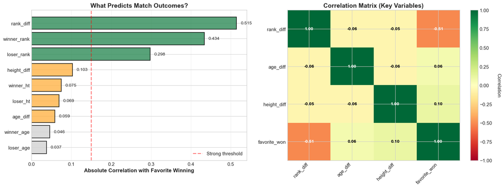

```
================================================================================
KEY INSIGHTS FROM EDA
================================================================================

1. RANKING IS DOMINANT:
   → rank_diff correlation: 0.515
   → Rankings are THE primary signal for predicting match outcomes

2. AGE DOESN'T MATTER:
   → age_diff correlation: 0.059
   → Weak effect at best

3. HEIGHT IS WEAK:
   → height_diff correlation: 0.103
   → Some advantage, but not a strong predictor

THE PROBLEM WITH ATP RANKINGS:
   Rankings clearly predict outcomes (strong correlation)
   BUT: ATP rankings update only WEEKLY (stale)
   ATP rankings don't weight opponent quality
   ATP rankings ignore surface specialization

THE OPPORTUNITY:
   → Build a BETTER ranking system (ELO)
   → Updates after EVERY match (real-time)
   → Weights opponent quality dynamically
   → Surface-specific ratings (Clay/Grass/Hard)

HYPOTHESIS:
   "A dynamic ELO system will capture player strength
   better than static ATP rankings, improving prediction accuracy"

================================================================================
```

### EDA Takeaways

**Ranking differential dominates** raw correlation analysis, confirming that player quality is the primary predictor.  
However, ATP rankings are a weekly snapshot — ELO (updated match-by-match) and serve style may capture  
dimensions that a single rank number misses. Sections 3.5 and 3.6 test this directly.

## Section 2: Feature Engineering

Three feature layers are constructed here, each requiring careful temporal discipline to prevent data leakage:

1. **ELO ratings** — custom Elo system updated after each match; pre-match rating captured *before* the update
2. **ATP-derived features** — ranking differentials, form windows, H2H records — all using `.shift(1)`
3. **Serve profile** — rolling historical serve percentages (9 metrics) using `.shift(1)`

All features are computed on the full dataset *before* the train/test split, which is correct because:

- ELO: updated only after each match chronologically, so pre-match ratings are already leakage-free
- Rolling features: `.shift(1)` guarantees only prior-match data is used
- The temporal split at the end ensures no test-period data ever influences training

```
match | won | form_WRONG (leaks current) | form_CORRECT (prior only)
 match  won  form_WRONG  form_CORRECT
     1    1    1.000000           NaN
     2    0    0.500000      1.000000
     3    1    0.666667      0.500000
     4    1    0.666667      0.666667
     5    0    0.666667      0.666667

Row 3 (match=3): WRONG = mean(1,0,1)=0.67 includes match 3's result.
                 CORRECT = mean(1,0)=0.50  uses only prior matches. ✅
```

### ELO Rating System

ELO assigns each player a numerical strength rating, updated after every match:

- **K=32** for overall rating — controls how fast ratings change
- **K=40** for surface-specific rating — higher K because players have less data per surface
- **Cold start**: New players begin at 1,500 (tour average). This is a known limitation — debut matches use average ratings regardless of actual quality.
- **Pre-match capture**: The rating *before* the match is stored as the feature. The update happens after.
- **Combined probability**: `elo_combined_prob = (overall_win_prob + surface_win_prob) / 2`

```
ELO Rating System implemented
```

```
Transformation validated: 25,245 matches → 50,490 player records
```

|  | tourney_id | tourney_name | surface | tourney_level | tourney_date | draw_size | best_of | round | player_name | player_id | player_rank | player_age | player_ht | opponent_name | opponent_rank | opponent_age | opponent_ht | player_hand | won |
| --- | --- | --- | --- | --- | --- | --- | --- | --- | --- | --- | --- | --- | --- | --- | --- | --- | --- | --- | --- |
| 0 | 2023-0451 | Doha | Hard | A | 20230220 | 32 | 3 | R32 | Abedallah Shelbayh | 209406 | 276.0 | 19.2 | 180.0 | Soon Woo Kwon | 68.0 | 25.2 | 180.0 | L | 0 |
| 1 | 2023-2841 | Banja Luka | Clay | A | 20230417 | 32 | 3 | R32 | Abedallah Shelbayh | 209406 | 267.0 | 19.4 | 180.0 | Elias Ymer | 139.0 | 27.0 | 185.0 | L | 1 |
| 2 | 2023-2841 | Banja Luka | Clay | A | 20230417 | 32 | 3 | R16 | Abedallah Shelbayh | 209406 | 267.0 | 19.4 | 180.0 | Miomir Kecmanovic | 33.0 | 23.6 | 183.0 | L | 0 |
| 3 | 2023-1536 | Madrid Masters | Clay | M | 20230424 | 128 | 3 | R128 | Abedallah Shelbayh | 209406 | 243.0 | 19.4 | 180.0 | Pedro Cachin | 67.0 | 28.0 | 185.0 | L | 0 |
| 4 | 2023-8994 | Mallorca | Grass | A | 20230626 | 32 | 3 | R32 | Abedallah Shelbayh | 209406 | 240.0 | 19.6 | 180.0 | Roman Safiullin | 94.0 | 25.8 | 185.0 | L | 0 |

```
Building ELO ratings chronologically...
Processing 50,490 records...
  Progress: 0 / 50,490
```

```
  Progress: 10,000 / 50,490
```

```
  Progress: 20,000 / 50,490
```

```
  Progress: 30,000 / 50,490
```

```
  Progress: 40,000 / 50,490
```

```
  Progress: 50,000 / 50,490

ELO ratings built successfully
   Overall ELO range: 1292 - 2225
   Mean ELO: 1605
```

```
HEIGHT (player_ht: winners vs losers)
  Winners mean     : 187.69
  Losers mean      : 186.77
  Point-biserial r : 0.0649
  Mann-Whitney p   : 4.4026e-51
  Effect size r    : 0.0670  (negligible)

AGE (player_age: winners vs losers)
  Winners mean     : 27.37
  Losers mean      : 27.51
  Point-biserial r : -0.0162
  Mann-Whitney p   : 9.8471e-05
  Effect size r    : 0.0173  (negligible)

NOTE: Statistical significance in large samples (n~50k) does not imply
practical significance. Effect size r < 0.1 is negligible regardless of p-value.
```

```
ATP features added to df_feat. Shape: (50490, 55)
```

```
Using 25,245 elite matches (reused from Section 1)
Player-level serve df: 50,490 rows
```

```
Tour-average defaults (first 1-2 matches per player):
  serve_win_pct: 0.638
  ace_rate: 0.072
  df_rate: 0.035
  first_in_pct: 0.615
  first_win_pct: 0.718
  second_win_pct: 0.515
  bp_save_pct: 0.594
  hold_pct: 0.776
  return_win_pct: 0.365

First-match serve_win_pct mean: 0.638 (should equal tour median 0.638)
```

```
df_v2 shape: (51322, 64)
Serve features added: ['serve_win_pct', 'ace_rate', 'df_rate', 'first_in_pct', 'first_win_pct', 'second_win_pct', 'bp_save_pct', 'hold_pct', 'return_win_pct']
All features available for progressive model building.
```

```
Feature subsets defined:
  physical_features  : 8 features
  serve_features     : 9 features
  atp_features       : 20 features
  elo_features       : 21 features  (atp + elo_combined_prob)
  elo_serve_features : 30 features  (elo + serve)

Temporal split (NEVER shuffle — train on past, test on future):
  Train 2015-2022: 40,172 records  (20,086 matches)
  Val   2023:      5,660 records  (2,830 matches)
  Test  2024:      5,490 records  (2,745 matches)
```

## Section 3: Progressive Model Building

Six models, each testing one null hypothesis. The design mirrors an incrementality study: start with the weakest possible predictor, then add feature layers and test whether each adds significant lift.

**Structure per hypothesis:**

1. State H₀ and feature set
2. Train model(s) on training split
3. Evaluate on 2024 test set (accuracy + ROC-AUC)
4. Bootstrap significance test vs the appropriate baseline

All models share the identical temporal split from Section 2. Variables produced here  
(`y_proba_h1` through `y_proba_h6`) are used in Sections 4–6.

### H1 — Context-Only Baseline

**H₀**: Physical attributes (age, height) and tournament context (surface, level, round) have no predictive power beyond random chance.

**Feature set**: `physical_features` — age, height, surface encoding, level, round, best_of  
**Model**: Logistic Regression  
**Significance test**: One-sided binomial test vs 50%

```
H1 — Context-Only Baseline (LR)
  Test Accuracy : 54.9%
  ROC-AUC       : 0.574  (vs 0.500 baseline)
  p-value vs 50%: 0.0000
  → REJECT H1: Physical context has statistically significant predictive power
```

### H2 — Serve Profile Only (No Rankings, No ELO)

**H₀**: Historical serve statistics have no predictive power when used without ATP rankings or ELO.

**Feature set**: `serve_features` — 9 rolling historical serve metrics (all `.shift(1)`)  
**Models**: Logistic Regression + Gradient Boosting  
**Baseline**: H1 context-only model (bootstrap AUC)

*This tests whether serve skill is an independent signal — separate from a player's ranking.*

```
H2 — Serve Features Only
  LR : Accuracy 57.6%, AUC 0.604
  GB : Accuracy 57.7%, AUC 0.608  ← selected if higher
```

```
  Bootstrap vs H1 (10,000 iters):
  AUC lift: +0.0331  95% CI [0.0138, 0.0518]  p=0.0005
  → REJECT H2: Serve stats have significant independent predictive power
```

### H3 — ATP Rankings

**H₀**: ATP rankings provide no information beyond physical attributes and context.

**Feature set**: `atp_features` — rank differential, form windows, H2H, surface win rates, workload  
**Model**: Gradient Boosting  
**Baseline**: H1 context-only model (bootstrap AUC)

*ATP rankings are the incumbent predictor. All subsequent models are benchmarked against H3.*

```
H3 — ATP Rankings (GB)
  Test Accuracy : 64.0%
  ROC-AUC       : 0.707
```

```
  Bootstrap vs H1 (10,000 iters):
  AUC lift: +0.1324  95% CI [0.1149, 0.1496]  p=0.0000
  → REJECT H3: ATP rankings significantly outperform physical context alone

  *** H3 AUC (0.707) is the PRIMARY benchmark for all subsequent models ***
```

### H4 — ATP Rankings + Serve Profile

**H₀**: Historical serve statistics add no predictive value when ATP rankings are already included.

**Feature set**: `atp_features + serve_features`  
**Models**: Logistic Regression + Gradient Boosting  
**Baseline**: H3 ATP-only model (bootstrap AUC)

*If serve adds lift here, it carries independent information not captured by a player's ranking.*

```
H4 — ATP Rankings + Serve Profile
  LR : Accuracy 63.7%, AUC 0.695
  GB : Accuracy 63.5%, AUC 0.706
```

```
  Bootstrap vs H3 ATP (10,000 iters):
  AUC lift: -0.0008  95% CI [-0.0036, 0.0020]  p=0.7146
  → FAIL TO REJECT H4: Serve statistics do not significantly improve on ATP rankings alone
```

### H5 — ELO Ratings

**H₀**: ELO ratings add no predictive information beyond ATP rankings.

```
H5 Model Selection (ELO features, validated on 2023):
  Gradient Boosting          Val AUC: 0.716  Test AUC: 0.721
  Random Forest              Val AUC: 0.711  Test AUC: 0.715
  Logistic Regression        Val AUC: 0.710  Test AUC: 0.716

H5 Selected: Logistic Regression
  Train: 66.6%  Val: 65.1%  Test: 64.7%  Gap: +1.5%
  Test AUC: 0.716
```

```
  Bootstrap vs H3 ATP (10,000 iters):
  AUC lift: +0.0088  95% CI [0.0010, 0.0165]  p=0.0124
  → REJECT H5: ELO provides significant lift over ATP rankings
```

### H6 — ELO + Serve Profile (V2 Model)

**H₀**: Serve profile features add no predictive value when ELO ratings are already included.

**Feature set**: `elo_serve_features` = `elo_features` + `serve_features` (9 additional metrics)  
**Models**: Logistic Regression + Gradient Boosting  
**Primary baseline**: H3 ATP rankings — *does ELO+Serve beat official rankings?*  
**Secondary baseline**: H5 ELO only — *does serve add anything once ELO is in?*

```
H6 — ELO + Serve Profile (V2)
  LR : Accuracy 64.9%, AUC 0.715
  GB : Accuracy 65.3%, AUC 0.722
```

```
  Bootstrap vs H3 ATP (PRIMARY, 10,000 iters):
  AUC lift: +0.0148  95% CI [0.0087, 0.0207]  p=0.0000

  Bootstrap vs H5 ELO (SECONDARY, 10,000 iters):
  AUC lift: +0.0059  95% CI [0.0015, 0.0104]  p=0.0043
  → REJECT H6 (vs ATP): ELO+Serve significantly beats official rankings
  → Serve features add significant lift beyond ELO alone
```

## Section 4: Validation & Diagnostics

All diagnostics use the **H5 ELO model** (LR) as the primary selected model.  
H6 (ELO+Serve) is shown alongside where it clarifies calibration or distributional differences.

```
======================================================================
OVERFITTING ANALYSIS  (H5 ELO Model — Logistic Regression)
======================================================================

  Train (2015-2022): 66.6%
  Val   (2023):      65.1%
  Test  (2024):      64.7%

  Train-Val gap: +1.5%
  Val-Test gap:  +0.4%
  ✓ EXCELLENT — No overfitting detected (gap < 3%)
```

[output not shown]

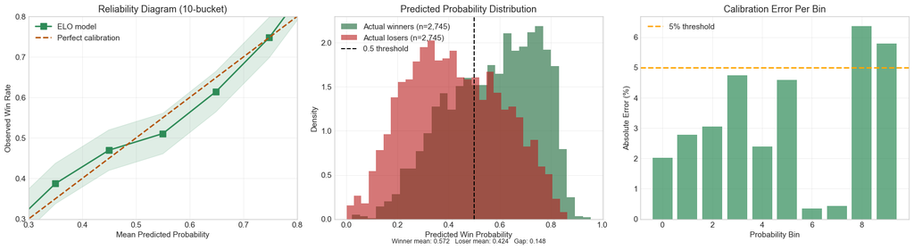

```
Calibration Summary:
  Mean Absolute Calibration Error: 3.2%
  Brier Score: 0.215  (lower is better; 0.25 = random)
  Log Loss:    0.617
```

[output not shown]

## Section 5: Model Comparison & Visualizations

[output not shown]

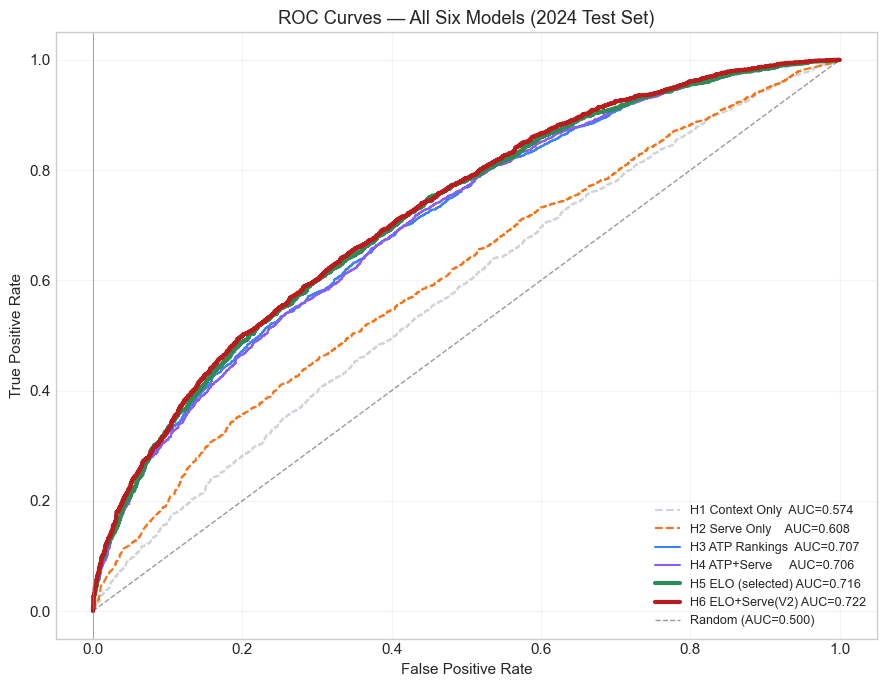

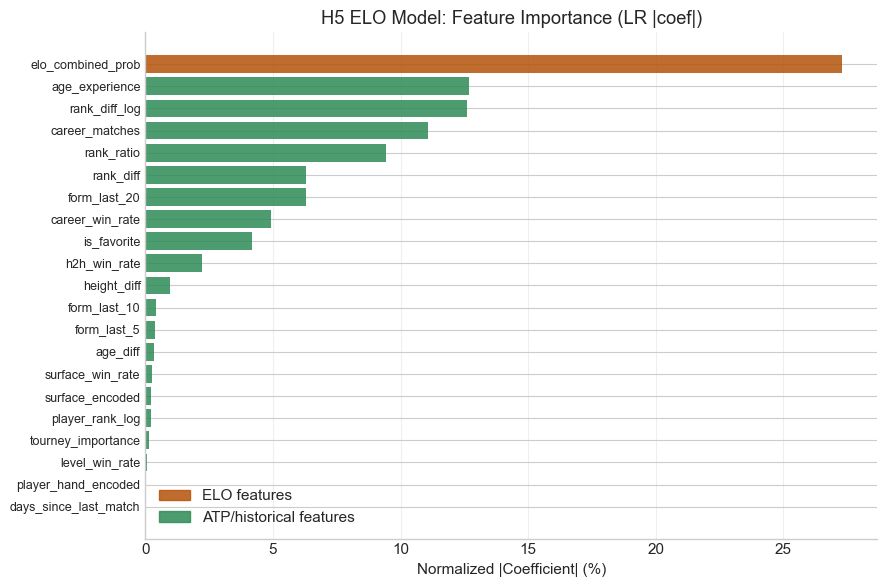

```
Note: LR |coef| is scale-dependent — larger coefficient may reflect feature scale, not importance.
              feature  importance
    elo_combined_prob    0.273023
       age_experience    0.126782
        rank_diff_log    0.125945
       career_matches    0.110924
           rank_ratio    0.094109
            rank_diff    0.063043
         form_last_20    0.062828
      career_win_rate    0.049341
          is_favorite    0.041650
         h2h_win_rate    0.022148
          height_diff    0.009618
         form_last_10    0.004151
          form_last_5    0.003938
             age_diff    0.003429
     surface_win_rate    0.002491
      surface_encoded    0.002108
      player_rank_log    0.002102
   tourney_importance    0.001317
       level_win_rate    0.000773
  player_hand_encoded    0.000218
days_since_last_match    0.000060
```

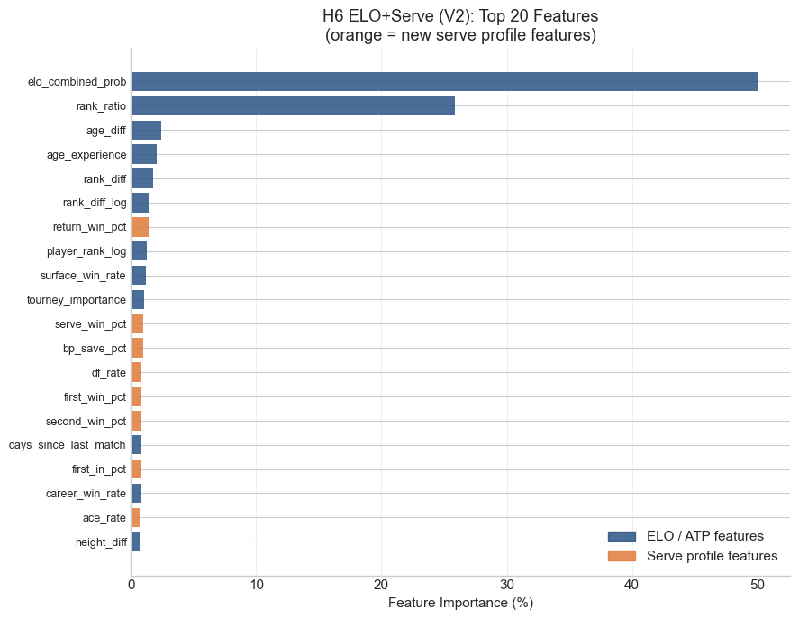

```
Serve features total importance: 7.4%
ELO/ATP features total importance: 92.6%
```

```
Segment                               Recs  Matches   Accuracy  95% Wilson CI             Edge
------------------------------------------------------------------------------------------
Overall                              5,490    2,745      64.7%  [63.5%, 66.0%]  +14.7%
Grand Slams                          1,016      508      72.6%  [69.8%, 75.3%]  +22.6%
Masters 1000                         1,390      695      65.5%  [62.9%, 67.9%]  +15.5%
ATP Tour                             3,084    1,542      61.8%  [60.1%, 63.5%]  +11.8%
Hard Court                           3,124    1,562      64.8%  [63.1%, 66.5%]  +14.8%
Clay Court                           1,718      859      64.8%  [62.5%, 67.0%]  +14.8%
Grass Court                            648      324      64.2%  [60.4%, 67.8%]  +14.2%
Top 10 players                         645      322      74.1%  [70.6%, 77.3%]  +24.1%
Close (ELO diff < 50)                1,437      718      56.4%  [53.9%, 59.0%]  +6.4%
Clear favourite (ELO>150)            1,777      888      76.3%  [74.3%, 78.2%]  +26.3%
```

## Section 6: Business Impact & Conclusions

```
KELLY CRITERION BETTING SIMULATION (2024 test set)
--------------------------------------------------
  Strategy: bet when model edge > 10%
  Position sizing: Kelly Criterion (capped 25%)
  Total matches: 5,490
  Bets placed:   391 (7.1%)
  Win rate:      60.1%
  Total wagered: 94.55 units
  P&L:           +45.09 units
  ROI:           +47.7%

⚠ This simulation uses model probs as implied odds, not actual bookmaker prices.
  Treat ROI as an illustration of calibration value, not a production backtest.
```

```
=================================================================
PRODUCTION READINESS CHECKLIST
=================================================================

  ✓ PASS  H5 ELO AUC exceeds H3 ATP baseline
         ELO 0.716 vs ATP 0.707 (+0.009)

  ✓ PASS  ELO improvement is significant (p < 0.05)
         Bootstrap p=0.0124, 95% CI [0.0010, 0.0165]

  ✓ PASS  Well-calibrated (mean cal error < 5%)
         3.2% mean absolute calibration error

  ✓ PASS  Minimal overfitting (train-val gap < 5pp)
         1.5% train-to-validation gap

  ✓ PASS  ELO adds over context-only (AUC gain > 0.10)
         ELO 0.716 vs context-only 0.574 (+0.141)

=================================================================
  OVERALL: 5/5 checks passed
=================================================================
```

### Research Question Answers

**Overarching question**: Can publicly available pre-match data — beyond official ATP rankings — predict match outcomes with statistically significant accuracy?

**Answer: See H5 and H6 bootstrap results above.** The key question is whether `p_h5 < 0.05`.

#### Hypothesis Summary (populated at runtime)

The code cells in Section 3 print specific p-values and CI bounds for each test. The table below is a reading guide — actual results are in the cell outputs.

| # | H₀ | Feature set | Benchmark | Reject if |
| --- | --- | --- | --- | --- |
| H1 | Context has no power | Physical + context | 50% random | p_h1 < 0.05 |
| H2 | Serve has no independent power | Serve only | H1 model | p_h2 < 0.05 |
| H3 | Rankings add nothing over context | ATP features | H1 model | p_h3 < 0.05 |
| H4 | Serve adds nothing to rankings | ATP + serve | H3 model | p_h4 < 0.05 |
| H5 | ELO adds nothing over rankings | ELO features | H3 model | p_h5 < 0.05 |
| H6 | Serve adds nothing to ELO | ELO + serve | H3 + H5 | p_h6_atp / p_h6_elo < 0.05 |

**Design note**: H3 (ATP rankings) is the primary benchmark because rankings are the "free" baseline any analyst has access to. A model is only valuable if it significantly clears that bar.

### Business Impact Context

This analysis mirrors a common problem in **marketing analytics and data science**: incrementality testing.

The question *"does ELO add lift over ATP rankings?"* is structurally identical to:

- *"Does this retargeting campaign add conversions beyond organic intent?"*
- *"Does this new data signal improve attribution beyond last-click?"*
- *"Does adding behavioural data improve churn prediction over CRM features alone?"*

In each case, the methodology is the same as used here:

1. Establish the incumbent baseline (ATP rankings / last-click / CRM only)
2. Build the challenger model with the new signal added
3. Bootstrap the AUC difference on held-out data to confirm significance before investing
4. Report lift with confidence intervals, not just point estimates

**Model limitations to communicate to stakeholders:**

1. **No bookmaker odds**: The Kelly simulation uses model probabilities as proxy odds. Real edge  
   requires comparison to closing-line prices — the simulation demonstrates calibration quality only.
2. **Cold-start ELO**: Players making their debut receive Elo=1,500 regardless of true strength.  
   This degrades accuracy for matches involving newcomers or comeback-from-injury first matches.
3. **Serve stat coverage**: ~1.1% of matches have missing serve data, filled with tour medians.  
   This introduces slight regression-to-mean bias in the H6 model for those matches.
4. **Temporal stability**: All models trained on 2015–2022. If playing styles or competition  
   dynamics shift substantially, recalibration against more recent data would be appropriate.